# 20250722 Root Atlas cNMF

This runs within the cnmf Conda environment

```python
import os
## Set directory
os.chdir('/resnick/groups/NolanLab/cchen/mannitol/cnmf/')
```

```python
## conda env
%matplotlib inline
%config InlineBackend.figure_format = 'retina'

import pandas as pd
import numpy as np
from scipy.io import mmread
import scipy.sparse as sp
import matplotlib.pyplot as plt
from IPython.display import Image
import scanpy as sc
from cnmf import cNMF
import plotly.graph_objects as gr_ob
from matplotlib.colors import LinearSegmentedColormap
from scipy.stats import fisher_exact
from statsmodels.stats.multitest import multipletests
import matplotlib.patches as patches
import seaborn as sns
import matplotlib.pyplot as plt
```

```python
# Set random seed
np.random.seed(101)
```

```python
# Read in the merged data
# Here I'm using the RNA assay because it's stress data and I'm afraid that batch correction would remove biological effects
# Batch correction option: https://github.com/dylkot/cNMF/blob/main/Tutorials/analyze_batcheffectcorrect_BaronEtAl.ipynb
adata = sc.read_h5ad("/resnick/groups/NolanLab/shared_resources/annotated_objects/h5ad/Root_Atlas_RNA_20241022.h5ad")
```

```python
adata
```

```
AnnData object with n_obs × n_vars = 110427 × 28958
    obs: 'orig.ident', 'time.celltype.anno.Li'
    var: 'features'
```

```python
adata.obs["orig.ident"].unique()
```

```
['sc_12', 'sc_11', 'sc_30', 'sc_31', 'sc_37', ..., 'tnw2', 'col0', 'pp1', 'dc1', 'dc2']
Length: 16
Categories (16, object): ['col0', 'dc1', 'dc2', 'pp1', ..., 'sc_40', 'sc_51', 'tnw1', 'tnw2']
```

## Run cNMF

```python
numiter=200 # Number of NMF replicates. Set this to a larger value ~200 for real data. We set this to a relatively low value here for illustration at a faster speed
numhvgenes=2000 ## Number of over-dispersed genes to use for running the actual factorizations

## Results will be saved to [output_directory]/[run_name] which in this example is example_PBMC/cNMF/pbmc_cNMF
output_directory = '20250722_root_atlas_cnmf'
if not os.path.exists(output_directory):
    os.mkdir(output_directory)
run_name = '20250722_root_atlas_cnmf_parallel'

## Specify the Ks to use as a space separated list
K = ' '.join([str(i) for i in range(2,51)])

seed = 101 ## Specify a seed pseudorandom number generation for reproducibility

## Path to the filtered counts dataset we output previously
countfn = "/resnick/groups/NolanLab/shared_resources/annotated_objects/h5ad/Root_Atlas_RNA_20241022.h5ad"
```

```python
K
```

```
'2 3 4 5 6 7 8 9 10 11 12 13 14 15 16 17 18 19 20 21 22 23 24 25 26 27 28 29 30 31 32 33 34 35 36 37 38 39 40 41 42 43 44 45 46 47 48 49 50'
```

```python
## Initialize the cnmf object that will be used to run analyses
cnmf_obj = cNMF(output_dir=output_directory, name=run_name)
```

```python
## Prepare the data, i.e. subset to 2000 high-variance genes, and variance normalize
# This step saves all the necessary information to disk in the output directory
# Later, when each worker runs, it reconstructs cnmf_obj from disk using that saved configuration
cnmf_obj.prepare(counts_fn=countfn,
                 components=np.arange(2, 51),
                 n_iter=200,
                 seed=101,
                 num_highvar_genes=2000)
```

## Then use 20250722_cnmf_root_atlas_array.q to submit array job to HPC

Because the parallelization code within jupyter notebook (above) doesn't work, so submit array jobs to achieve parallelization, or else it takes too long to run (~1 week for 10 k numbers)

```python
## Combine results after factorization is done
cnmf_obj.combine()
```

[output not shown]

## Stability and Error plot

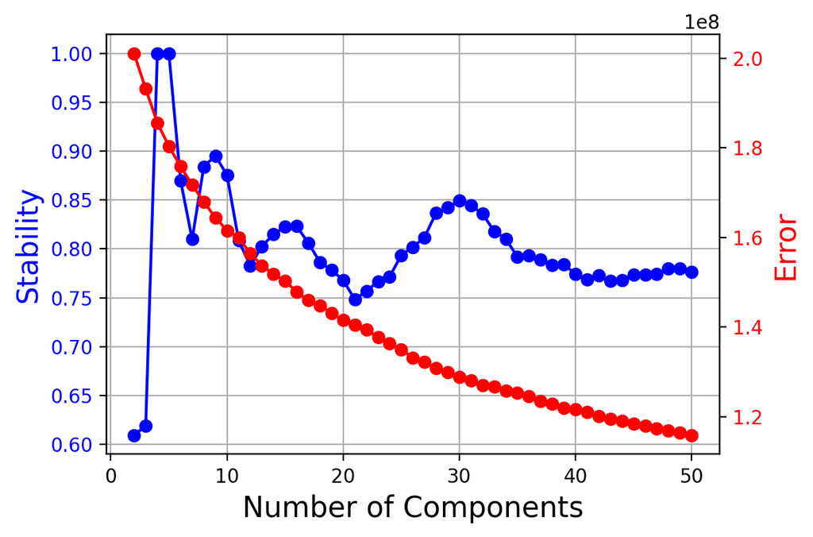

```python
cnmf_obj.k_selection_plot(close_fig=False)
```

## Filtering unstable components (GEP) using Euclidean distance

To ensure that only stable and biologically meaningful GEPs are retained, cNMF filters out noisy or inconsistent components based on their similarity across replicate runs. Each replicate of NMF yields a set of K components (GEPs), resulting in many total components across R replicates. Each component is represented as a vector of gene weights (i.e., a row in the G matrix).

For each component, cNMF computes the Euclidean distance to its L nearest components (neighbors) from other replicates. This measures how similar the component is to others in gene space. A component is retained only if its average distance to these L nearest neighbors is below a threshold (density_threshold). Components with high average distance are considered outliers and discarded.

True biological programs should appear repeatedly and consistently across replicates, forming tight clusters in gene space. Spurious or noisy programs will be inconsistent across replicates and lie far from others. By filtering based on Euclidean distance, cNMF keeps only reproducible programs and improves robustness of the consensus result.

```python
# Arguments in the consensus function
help(cnmf_obj.consensus)
```

```
Help on method consensus in module cnmf.cnmf:

consensus(k, density_threshold=0.5, local_neighborhood_size=0.3, show_clustering=True, build_ref=True, skip_density_and_return_after_stats=False, close_clustergram_fig=False, refit_usage=True, normalize_tpm_spectra=False, norm_counts=None) method of cnmf.cnmf.cNMF instance
    Obtain consensus estimates of spectra and usages from a cNMF run and output a clustergram of
    the consensus matrix. Assumes prepare, factorize, and combine steps have already been run.


    Parameters
    ----------
    k : int
        Number of programs (must be within the k values specified in previous steps)

    density_threshold : float (default: 0.5)
        Threshold for filtering outlier spectra. 2.0 or greater applies no filter.

    local_neighborhood_size : float (default: 0.3)
        Determines number of neighbors to use for calculating KNN distance as local_neighborhood_size X n_iters

    show_clustering : boolean (default=False)
        If True, generates the consensus clustergram filter

    build_ref : boolean (default=True)
        If True, generates reference spectra for use in starCAT

    skip_density_and_return_after_stats : boolean (default=False)
        True when running k_selection_plot to compute stability and error for input parameters without computing
        consensus spectra and usages

    close_clustergram_fig : boolean (default=False)
        If True, closes the clustergram figure from output after saving the image to a file

    refit_usage : boolean (default=True)
        If True, refit the usage matrix one final time after finalizing the spectra_tpm matrix. Done by regressing
        the tpm matrix against the tpm_spectra including only high-variance genes and with both the tpm matrix
        and tpm_spectra normalized by the standard deviations of the genes in tpm scale.

    normalize_tpm_spectra : boolean (default=False)
        If True, renormalizes the tpm_spectra to sum to 1e6 for each program. This is done before refitting usages.
        If not used, the tpm_spectra are exactly as calcuated when refitting the usage matrix against the tpm matrix
        and typically will not sum to the same value for each program.

    norm_counts : AnnData (default=None)
        Speed up calculation of k_selection_plot by avoiding reloading norm_counts for each K. Should not be used by
        most users
```

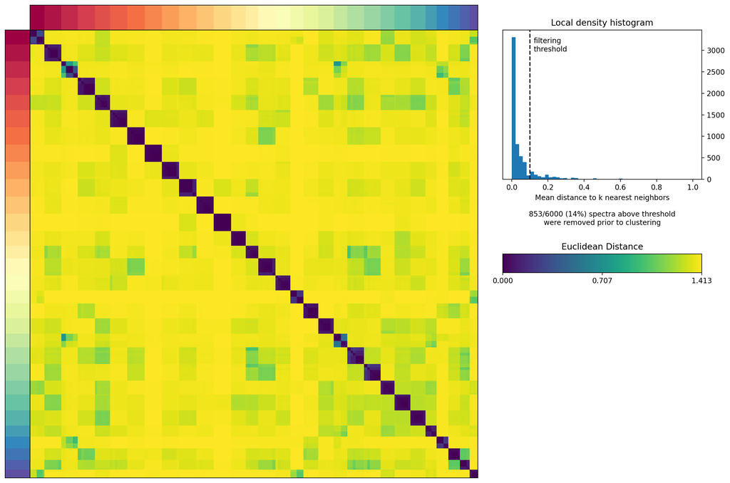

```python
# K = 30
cnmf_obj.consensus(k=30, density_threshold=0.1)
```

```python
# Create the result outputs in the folder
usage, spectra_scores, spectra_tpm, top_genes = cnmf_obj.load_results(K=30, density_threshold=0.1)
```

```python
# Check if the output files are there, ! is a magic operator for running shell commands directly from a notebook cell
# For the output format explanation, see: https://github.com/dylkot/cNMF
# Z-score unit gene expression program matrix: gene_spectra_score.txt
# TPM unit gene expression program matrix: gene_spectra_tpm.txt
# Usage matrix: consensus.txt
# K selection plot: k_selection.png
# Clustergram diagnostic plot: clustering.png
! ls /resnick/groups/NolanLab/cchen/mannitol/cnmf/20250722_root_atlas_cnmf/20250722_root_atlas_cnmf_parallel
```

```
20250722_root_atlas_cnmf_parallel.clustering.k_30.dt_0_1.png
20250722_root_atlas_cnmf_parallel.gene_spectra_score.k_30.dt_0_1.txt
20250722_root_atlas_cnmf_parallel.gene_spectra_tpm.k_30.dt_0_1.txt
20250722_root_atlas_cnmf_parallel.k_selection.png
20250722_root_atlas_cnmf_parallel.k_selection_stats.df.npz
20250722_root_atlas_cnmf_parallel.overdispersed_genes.txt
20250722_root_atlas_cnmf_parallel.spectra.k_30.dt_0_1.consensus.txt
20250722_root_atlas_cnmf_parallel.starcat_spectra.k_30.dt_0_1.txt
20250722_root_atlas_cnmf_parallel.usages.k_30.dt_0_1.consensus.txt
cnmf_tmp
```

```python
os.getcwd()
```

```
'/resnick/groups/NolanLab/cchen/mannitol/cnmf'
```

```python
# Load normalized usages, spectra, and a list of top genes directly from the cnmf object
# The topgenes variable returned by load_results() contains the top ranked 100 genes for each GEP based on the gene_spectra_score.
normalized_usage_matrix, gep_scores, gep_tpm, topgenes = cnmf_obj.load_results(K=30, density_threshold=0.1)
```

```python
help(cnmf_obj.load_results)
```

```
Help on method load_results in module cnmf.cnmf:

load_results(K, density_threshold, n_top_genes=100, norm_usage=True) method of cnmf.cnmf.cNMF instance
    Loads normalized usages and gene_spectra_scores for a given choice of K and
    local_density_threshold for the cNMF run. Additionally returns a DataFrame of
    the top genes linked to each program

    Parameters
    ----------
    K : int
        Number of programs (must be within the k values specified in previous steps)

    density_threshold : float
        Threshold for filtering outlier spectra (must be within the values specified in consensus step)

    n_top_genes : integer, optional (default=100)
        Number of top genes per program to return

    norm_usage : boolean, optional (default=True)
        If True, normalize cNMF usages to sum to 1

    Returns
    ----------
    usage - cNMF usages (cells X K)
    spectra_scores - Z-score coeffecients for each program (K x genes) with high values cooresponding
                to better marker genes
    spectra_tpm - Coeffecients for contribution of each gene to each program (K x genes) in TPM units
    top_genes - ranked list of marker genes per GEP (n_top_genes X K)
```

```python
gep_scores.head()
```

|  | 1 | 2 | 3 | 4 | 5 | 6 | 7 | 8 | 9 | 10 | ... | 21 | 22 | 23 | 24 | 25 | 26 | 27 | 28 | 29 | 30 |
| --- | --- | --- | --- | --- | --- | --- | --- | --- | --- | --- | --- | --- | --- | --- | --- | --- | --- | --- | --- | --- | --- |
| AT1G01010 | -0.000918 | -0.000449 | -0.000904 | 0.000053 | 0.000019 | -0.000163 | -0.000538 | -0.000526 | 0.002932 | -6.148138e-05 | ... | -0.000003 | -0.000611 | -0.000151 | 0.000103 | -0.000227 | 3.507503e-04 | -0.000168 | -0.000149 | -1.151191e-04 | 2.233542e-04 |
| AT1G01020 | -0.000036 | 0.000268 | -0.000233 | -0.000134 | 0.000773 | -0.000113 | 0.000124 | -0.000402 | 0.000288 | -1.836733e-04 | ... | 0.000245 | -0.000026 | -0.000146 | 0.000148 | 0.000162 | 3.322189e-04 | -0.000034 | 0.000142 | 7.106826e-05 | -2.479525e-05 |
| AT1G03987 | -0.000006 | -0.000004 | 0.000046 | -0.000011 | -0.000008 | -0.000008 | -0.000011 | -0.000010 | -0.000008 | 7.104151e-08 | ... | -0.000009 | -0.000005 | -0.000004 | -0.000008 | -0.000001 | 9.708034e-07 | -0.000003 | -0.000007 | -8.340389e-07 | -8.712404e-07 |
| AT1G01030 | 0.000060 | -0.000126 | 0.000092 | -0.000279 | -0.000195 | -0.000052 | -0.000141 | -0.000451 | -0.000140 | 1.716998e-03 | ... | 0.000403 | -0.000163 | -0.000090 | 0.000056 | 0.000045 | -1.224061e-04 | -0.000063 | -0.000004 | 8.596555e-06 | -1.130477e-04 |
| AT1G01040 | -0.000328 | -0.000093 | -0.000133 | 0.000053 | -0.000164 | -0.000138 | -0.000211 | -0.000035 | 0.000131 | 2.383958e-04 | ... | -0.000222 | 0.000295 | 0.000155 | -0.000132 | 0.000006 | 1.942994e-04 | -0.000200 | -0.000077 | -3.206050e-05 | -4.143671e-05 |

5 rows × 30 columns

```python
topgenes
```

|  | 1 | 2 | 3 | 4 | 5 | 6 | 7 | 8 | 9 | 10 | ... | 21 | 22 | 23 | 24 | 25 | 26 | 27 | 28 | 29 | 30 |
| --- | --- | --- | --- | --- | --- | --- | --- | --- | --- | --- | --- | --- | --- | --- | --- | --- | --- | --- | --- | --- | --- |
| 0 | AT5G10130 | AT2G19730 | AT1G50060 | AT1G77690 | AT1G03850 | AT1G12090 | AT1G05660 | AT4G30450 | AT3G60450 | AT1G05260 | ... | AT5G12020 | AT5G02640 | AT2G28760 | AT5G65360 | AT4G13420 | AT3G01940 | AT5G48920 | AT1G50490 | AT1G61760 | AT1G64000 |
| 1 | AT1G54010 | AT5G02960 | AT4G27400 | AT2G13820 | AT2G43820 | AT2G45180 | AT2G43890 | AT4G33550 | AT3G03990 | AT4G11290 | ... | AT5G12030 | AT5G50950 | AT2G28315 | AT1G07820 | AT4G22690 | AT3G01680 | AT4G22920 | AT5G16250 | AT1G54400 | AT5G09530 |
| 2 | AT4G37160 | AT3G62870 | AT1G25275 | AT1G12080 | AT5G17460 | AT1G20190 | AT3G08030 | AT1G20160 | AT1G10370 | AT5G57620 | ... | AT1G54050 | AT1G55210 | AT5G12870 | AT3G27360 | AT1G67980 | AT3G17730 | AT1G43790 | AT3G51280 | AT2G34530 | AT4G38080 |
| 3 | AT2G43610 | AT5G15200 | AT3G61930 | AT5G03960 | AT5G49450 | AT5G13930 | AT2G33790 | AT3G53980 | AT2G30400 | AT2G22000 | ... | AT2G29500 | AT1G68810 | AT4G18780 | AT3G45980 | AT1G02930 | AT5G46530 | AT3G21550 | AT5G66230 | AT5G41470 | AT1G55990 |
| 4 | AT2G23630 | AT4G16720 | AT5G54370 | AT2G46890 | AT4G33666 | AT1G76090 | AT1G13590 | AT2G30860 | AT3G16330 | AT4G05100 | ... | AT1G53540 | AT3G21270 | AT5G15630 | AT5G10400 | AT3G47480 | AT1G29520 | AT4G18425 | AT3G11520 | AT4G00890 | AT4G14440 |
| ... | ... | ... | ... | ... | ... | ... | ... | ... | ... | ... | ... | ... | ... | ... | ... | ... | ... | ... | ... | ... | ... |
| 95 | AT1G73340 | AT3G06700 | AT1G19020 | AT3G61640 | AT5G13750 | AT4G12520 | AT2G43880 | AT2G27510 | AT3G54140 | AT1G08847 | ... | AT1G56600 | AT5G48740 | AT3G08500 | AT5G02220 | AT5G59530 | AT5G60200 | AT2G28250 | AT1G04425 | AT1G02950 | AT2G17650 |
| 96 | AT4G36250 | AT4G15000 | AT1G19180 | AT4G17460 | AT4G11600 | AT4G30430 | AT1G69510 | AT5G09650 | AT2G45210 | AT3G61430 | ... | AT5G04340 | AT3G11490 | AT1G09610 | AT4G01270 | AT1G06983 | AT5G57130 | AT2G44260 | AT3G01295 | AT5G62960 | AT1G51890 |
| 97 | AT1G47620 | AT1G09590 | AT3G20300 | AT1G25500 | AT1G15100 | AT1G63330 | AT5G10260 | AT4G34600 | AT5G46590 | AT5G62500 | ... | AT1G29640 | AT3G22830 | AT2G26800 | AT1G26840 | AT4G39940 | AT4G37450 | AT2G44250 | AT3G61117 | AT1G16025 | AT4G35160 |
| 98 | AT4G11610 | AT5G57290 | AT5G38200 | AT1G25530 | AT1G21360 | AT1G76640 | AT2G37250 | AT4G29100 | AT4G21680 | AT3G13520 | ... | AT1G73740 | AT2G46760 | AT2G29050 | AT5G49010 | AT4G28420 | AT4G20270 | AT5G38610 | AT4G05520 | AT4G15970 | AT3G56970 |
| 99 | AT1G23160 | AT5G59850 | AT1G09070 | AT5G35670 | AT4G12040 | AT5G03150 | AT1G23060 | AT4G22570 | AT5G20020 | AT5G06730 | ... | AT1G07350 | AT1G02640 | AT4G35550 | AT4G06200 | AT3G54640 | AT2G44830 | AT5G14602 | AT5G01420 | AT3G47190 | AT4G24140 |

100 rows × 30 columns

```python
# Save topgenes
#topgenes.to_csv("20250722_root_atlas_cnmf/20250722_root_atlas_cnmf_parallel_top100_genes.txt",
#                sep="\t", index=False)
```